# Data Visualization I

STA199

8-30-2021

# Main Ideas

- Data visualization is an **extremely** effective way to express information and extract meaning from data.
- We can build up an effective visualization systematically layer by layer using a grammar of graphics (`ggplot2`).

# Coming Up

- Lab 1 due Tuesday.
- Homework 1 released on Wednesday.
- Lab 2 is on Friday.

“The simple graph has brought more information to the data analyst’s mind than any other device” - John Tukey

# Lecture Notes and Exercises

## Reminder

Before we start the exercise, we need to configure git so that RStudio can communicate with GitHub. This requires two pieces of information: your email address and your GitHub username.

Type the following lines of code in the **console** in RStudio, filling in your username and the email address associated with your GitHub account.

```r
library(usethis)
use_git_config(user.name= "github username", user.email="your email")
```

Next load the `tidyverse` package. Recall, a package is just a bundle of shareable code.

```r
library(tidyverse)
```

Exploratory data analysis (EDA) is an approach to analyzing datasets in order to summarize the main characteristics, often with visual representations of the data (today). We can also calculate summary statistics and perform data wrangling, manipulation, and transformation (next week).

We will use `ggplot2` to construct visualizations. The gg in `ggplot2` stands for “grammar of graphics”, a system or framework that allows us to describe the components of a graphic, building up an effective visualization layer by later.

## Minneapolis Housing Data

We will introduce visualization using data on single-family homes sold in Minneapolis, Minnesota between 2005 and 2015.

**Question:** What happens when you click the green arrow in the code chunk below? What changes in the “Environment” pane?

```r
mn_homes <- read_csv("~/mn_homes.csv")
```

```r
glimpse(mn_homes)
```

```
## Rows: 495
## Columns: 13
## $ saleyear      <dbl> 2012, 2014, 2005, 2010, 2010, 2013, 2011, 2007, 2013, 2…
## $ salemonth     <dbl> 6, 7, 7, 6, 2, 9, 1, 9, 10, 6, 7, 8, 5, 2, 7, 6, 10, 6,…
## $ salesprice    <dbl> 690467.0, 235571.7, 272507.7, 277767.5, 148324.1, 24287…
## $ area          <dbl> 3937, 1440, 1835, 2016, 2004, 2822, 2882, 1979, 3140, 3…
## $ beds          <dbl> 5, 2, 2, 3, 3, 3, 4, 3, 4, 3, 3, 3, 2, 3, 3, 6, 2, 3, 2…
## $ baths         <dbl> 4, 1, 1, 2, 1, 3, 3, 2, 2, 2, 2, 2, 2, 1, 2, 2, 2, 2, 1…
## $ stories       <dbl> 2.5, 1.7, 1.7, 2.5, 1.0, 2.0, 1.7, 1.5, 1.5, 2.5, 1.0, …
## $ yearbuilt     <dbl> 1907, 1919, 1913, 1910, 1956, 1934, 1951, 1929, 1940, 1…
## $ neighborhood  <chr> "Lowry Hill", "Cooper", "Hiawatha", "King Field", "Shin…
## $ community     <chr> "Calhoun-Isles", "Longfellow", "Longfellow", "Southwest…
## $ lotsize       <dbl> 6192, 5160, 5040, 4875, 5060, 6307, 6500, 5600, 6350, 7…
## $ numfireplaces <dbl> 0, 0, 0, 0, 0, 2, 2, 0, 1, 0, 0, 0, 0, 1, 1, 1, 0, 1, 0…
## $ fireplace     <lgl> FALSE, FALSE, FALSE, FALSE, FALSE, TRUE, TRUE, FALSE, T…
```

**Question:** What does each row represent? Each column?

[Write your answer here, you will do this for questions like this in your RMD file.]

### First Visualization

`ggplot` creates the initial base coordinate system that we will add layers to. We first specify the dataset we will use with `data = mn_homes`. The `mapping` argument is paired with an aesthetic (`aes`), which tells us how the variables in our dataset should be mapped to the visual properties of the graph.

**Question:** What does the code chunk below do?

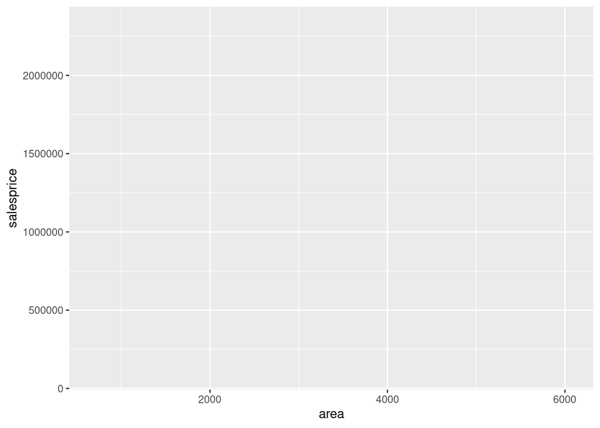

```r
ggplot(data = mn_homes,
       mapping = aes(x = area, y = salesprice))
```

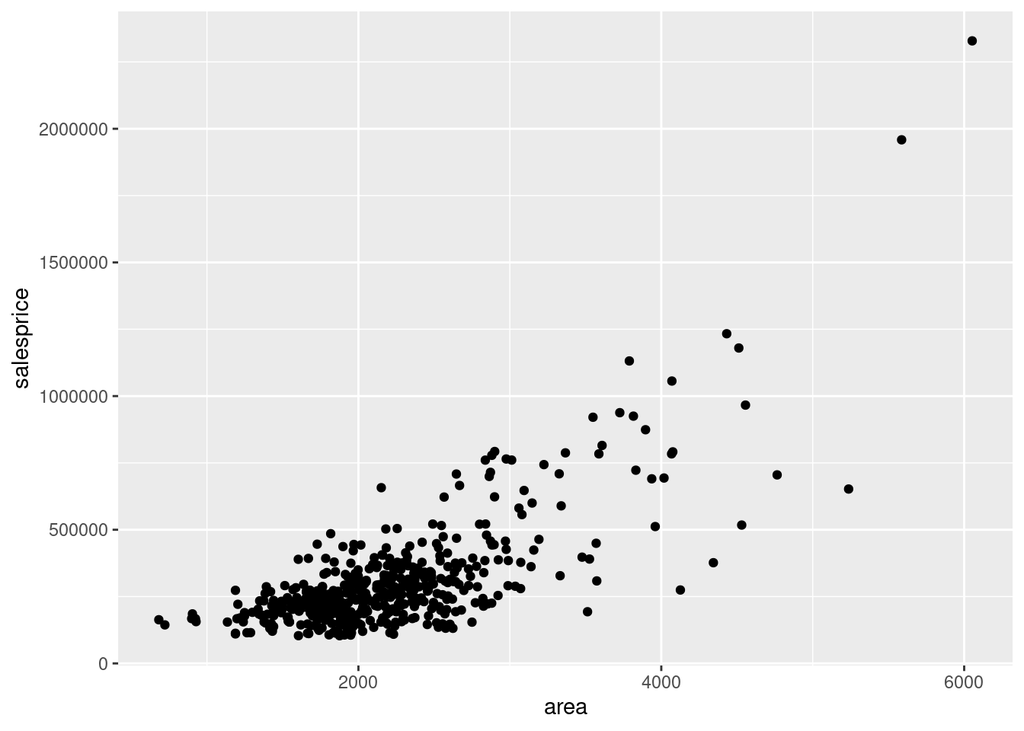

```r
ggplot(data = mn_homes,
       mapping = aes(x = area, y = salesprice)) +
   geom_point()
```

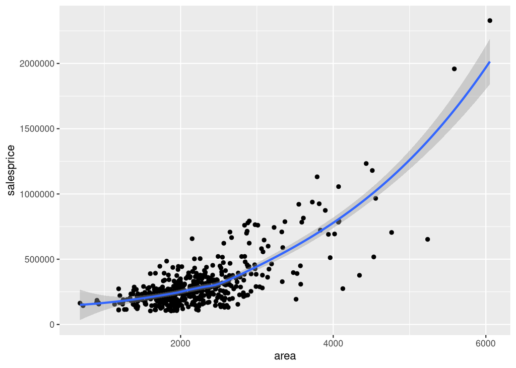

```r
ggplot(data = mn_homes,
       mapping = aes(x = area, y = salesprice)) +
   geom_point() +
   geom_smooth()
```

Run `?geom_smooth` in the console. What does this function do?

This fits a loess regression line (moving regression) to the data.

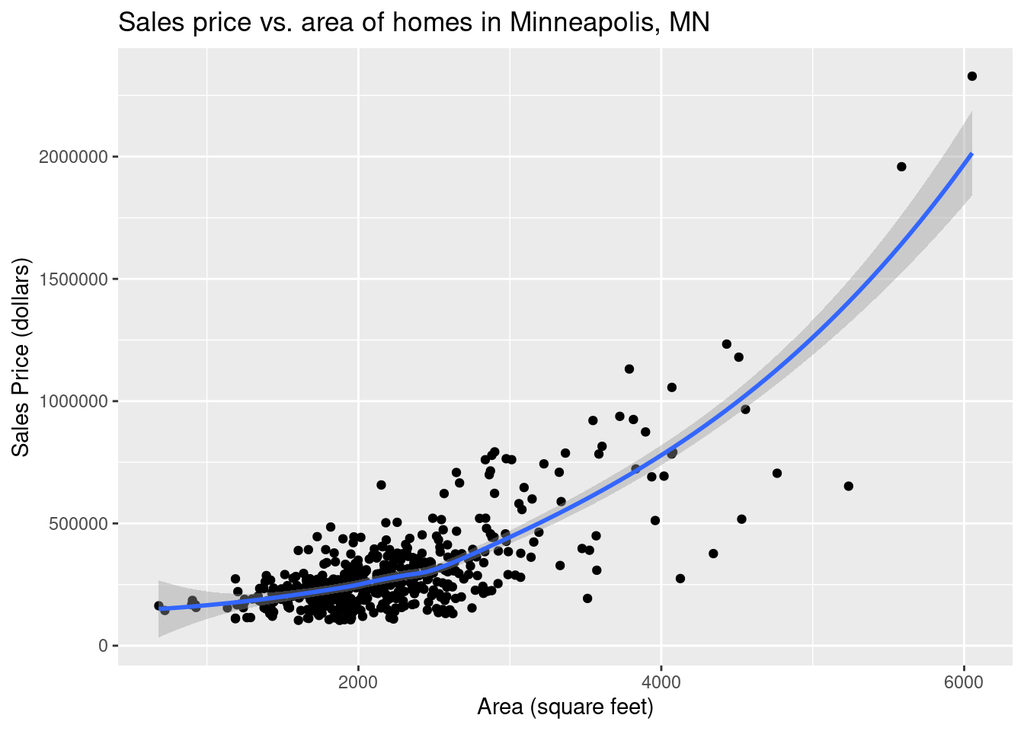

```r
ggplot(data = mn_homes,
       mapping = aes(x = area, y = salesprice)) +
   geom_point() +
   geom_smooth() +
   labs(title = "Sales price vs. area of homes in Minneapolis, MN",
        x = "Area (square feet)", y = "Sales Price (dollars)")
```

The procedure used to construct plots can be summarized using the code below.

```r
ggplot(data = [dataset],
       mapping = aes(x = [x-variable], y = [y-variable])) +
   geom_xxx() +
   geom_xxx() +
  other options
```

**Question:** What do you think `eval = FALSE` is doing in the code chunk above?

## Aesthetics

An aesthetic is a visual property of one of the objects in your plot.

- shape
- color
- size
- alpha (transparency)

We can map a variable in our dataset to a color, a size, a transparency, and so on. The aesthetics that can be used with each `geom_` can be found in the documentation.

**Question:** What will the visualization look like below? Write your answer down before running the code.

Here we are going to use the viridis package, which has more color-blind accessible colors. `scale_color_viridis` specifies which colors you want to use. You can learn more about the options [here](https://www.rdocumentation.org/packages/viridis/versions/0.5.1/topics/scale_color_viridis).

Other sources that can be helpful in devising accessible color schemes include [Color Brewer](https://colorbrewer2.org/#type=sequential&scheme=BuGn&n=3), the [Wes Anderson package](https://github.com/karthik/wesanderson), and the [cividis package](https://github.com/marcosci/cividis).

This visualization shows a scatterplot of area (x variable) and sales price (y variable). Using the viridis function, we make points for houses with a fireplace yellow and those without purple. We also add axis and an overall label.

```r
library(viridis)
```

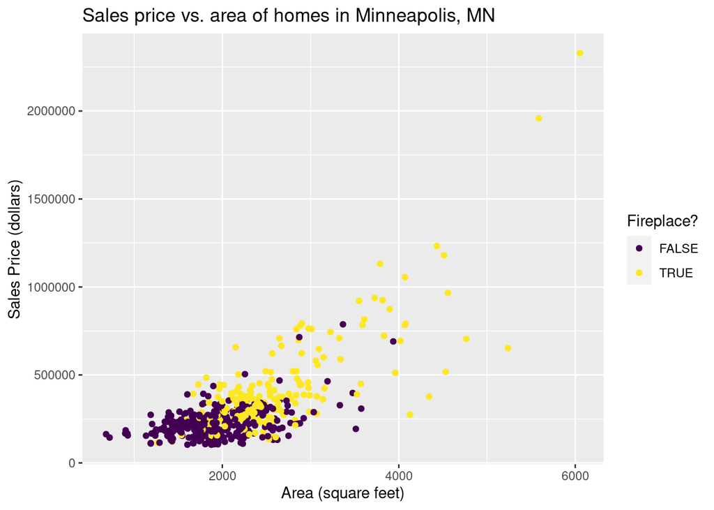

```r
ggplot(data = mn_homes,
       mapping = aes(x = area, y = salesprice,
                     color = fireplace)) +
   geom_point() +
   labs(title = "Sales price vs. area of homes in Minneapolis, MN",
        x = "Area (square feet)", y = "Sales Price (dollars)") +
        scale_color_viridis(discrete=TRUE, option = "D", name="Fireplace?")
```

**Question:** What about this one?

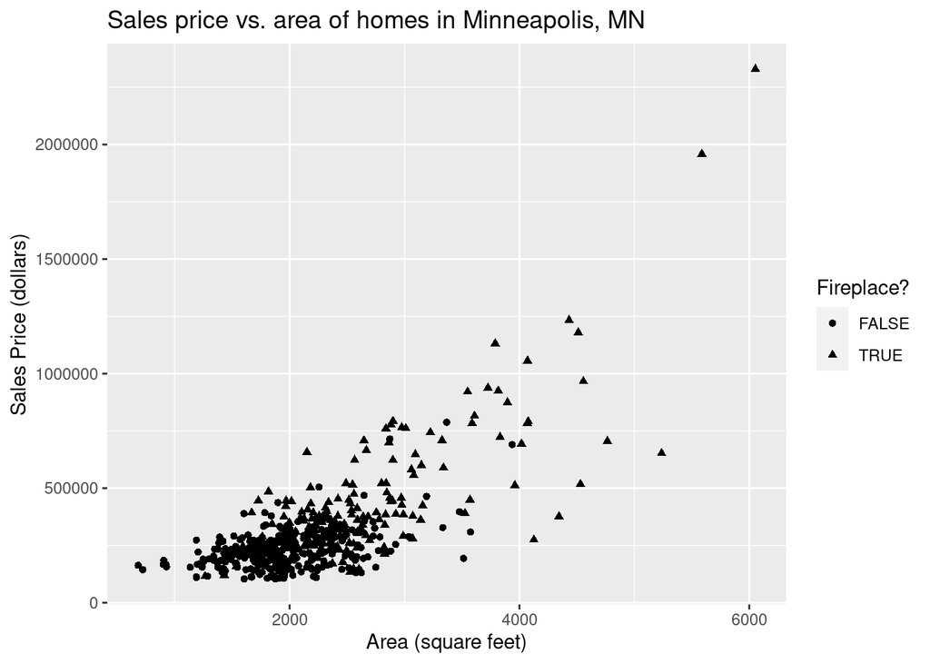

```r
ggplot(data = mn_homes,
       mapping = aes(x = area, y = salesprice,
                     shape = fireplace)) +
   geom_point() +
   labs(title = "Sales price vs. area of homes in Minneapolis, MN",
        x = "Area (square feet)", y = "Sales Price (dollars)",
        shape="Fireplace?")
```

**Question:** This one?

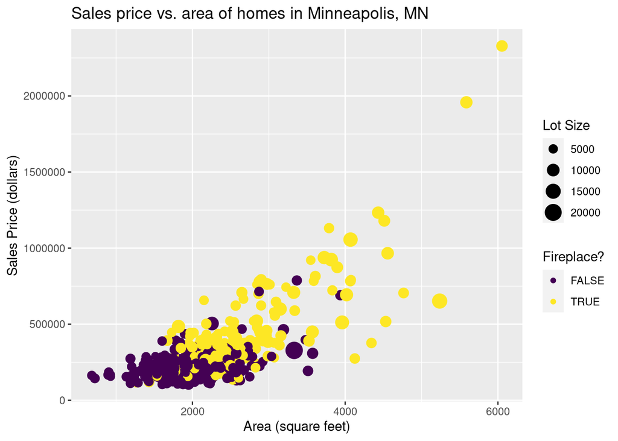

```r
ggplot(data = mn_homes,
       mapping = aes(x = area, y = salesprice,
                     color = fireplace,
                     size = lotsize)) +
   geom_point() +
   labs(title = "Sales price vs. area of homes in Minneapolis, MN",
        x = "Area (square feet)", y = "Sales Price (dollars)",
        size = "Lot Size") +
  scale_color_viridis(discrete=TRUE, option = "D",name="Fireplace?")
```

**Question:** Are the above visualizations effective? Why or why not? How might you improve them?

**Question:** What is the difference between the two plots below?

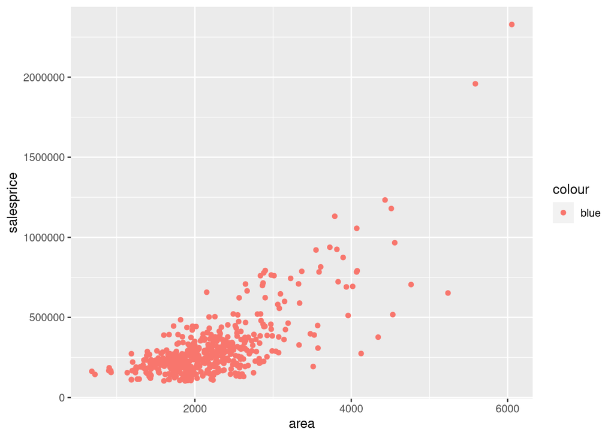

```r
ggplot(data = mn_homes) +
  geom_point(mapping = aes(x = area, y = salesprice, color = "blue"))
```

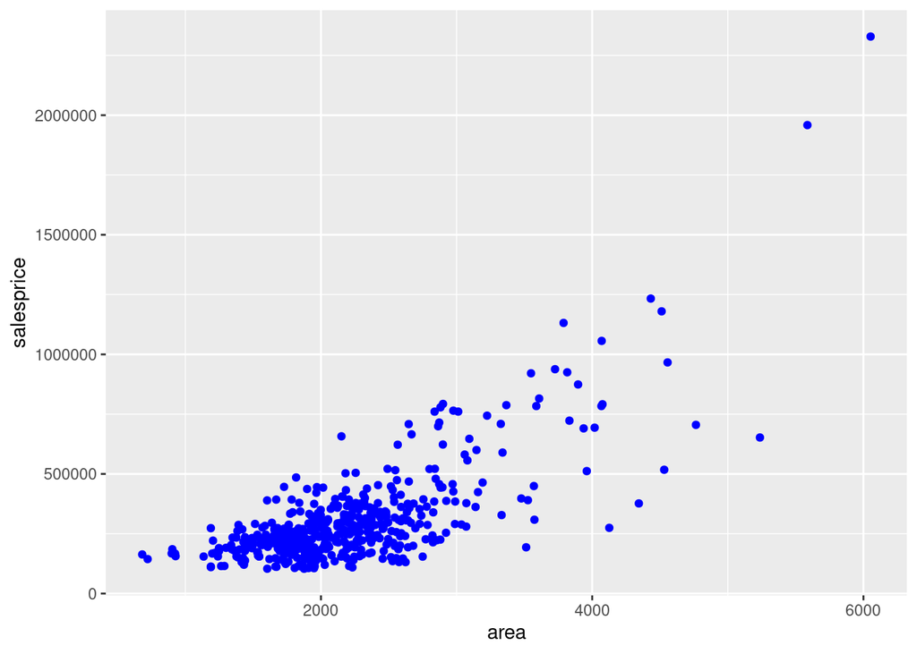

```r
ggplot(data = mn_homes) +
  geom_point(mapping = aes(x = area, y = salesprice), color = "blue")
```

Use `aes` to map variables to plot features, use arguments in `geom_xxx` for customization not mapped to a variable.

Mapping in the `ggplot` function is global, meaning they apply to every layer we add. Mapping in a particular `geom_xxx` function treats the mappings as local.

**Question:** Create a scatterplot using variables of your choosing using the `mn_homes` data.

**Question:** Modify your scatterplot above by coloring the points for each community.

## Faceting

We can use smaller plots to display different subsets of the data using faceting. This is helpful to examine conditional relationships.

Let’s try a few simple examples of faceting. Note that these plots should be improved by careful consideration of labels, aesthetics, etc.

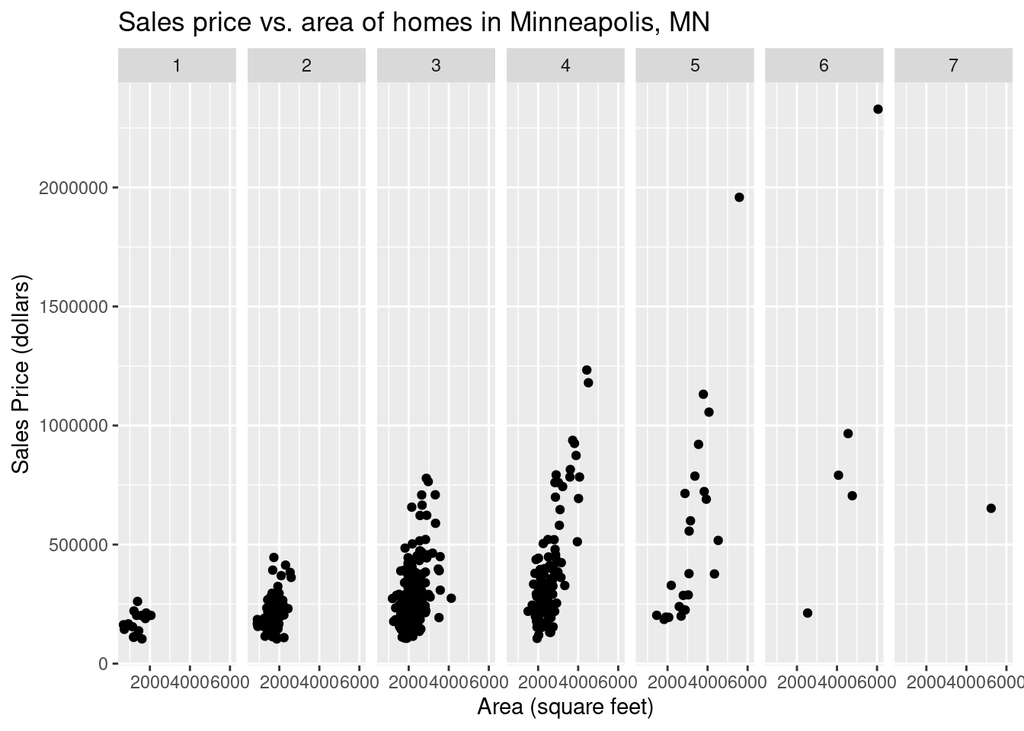

```r
ggplot(data = mn_homes,
       mapping = aes(x = area, y = salesprice)) +
   geom_point() +
   labs(title = "Sales price vs. area of homes in Minneapolis, MN",
        x = "Area (square feet)", y = "Sales Price (dollars)") +
   facet_grid(. ~ beds)
```

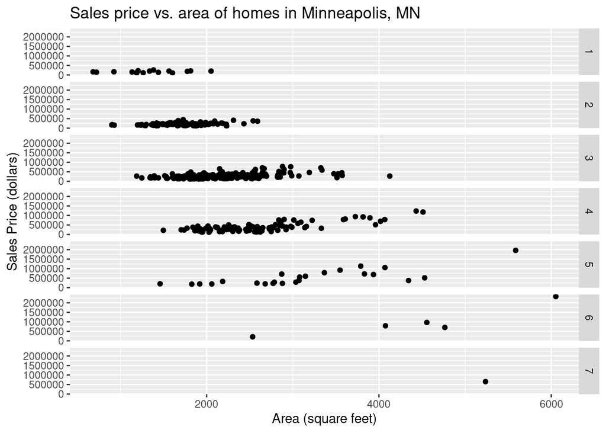

```r
ggplot(data = mn_homes,
       mapping = aes(x = area, y = salesprice)) +
   geom_point() +
   labs(title = "Sales price vs. area of homes in Minneapolis, MN",
        x = "Area (square feet)", y = "Sales Price (dollars)") +
   facet_grid(beds ~ .)
```

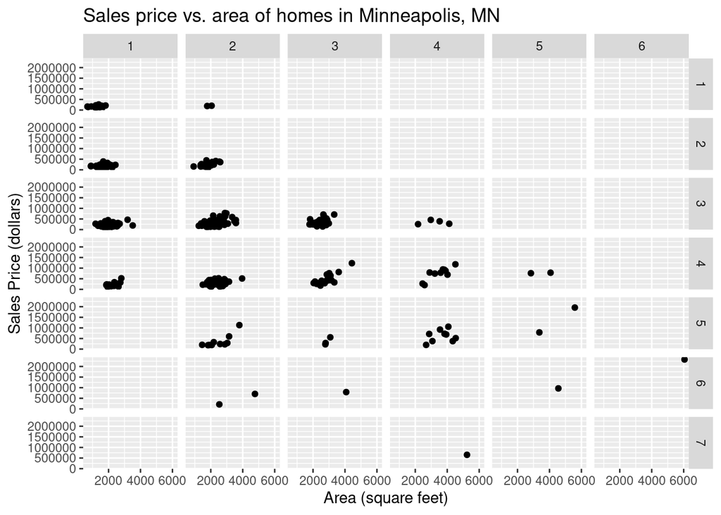

```r
ggplot(data = mn_homes,
       mapping = aes(x = area, y = salesprice)) +
   geom_point() +
   labs(title = "Sales price vs. area of homes in Minneapolis, MN",
        x = "Area (square feet)", y = "Sales Price (dollars)") +
   facet_grid(beds ~ baths)
```

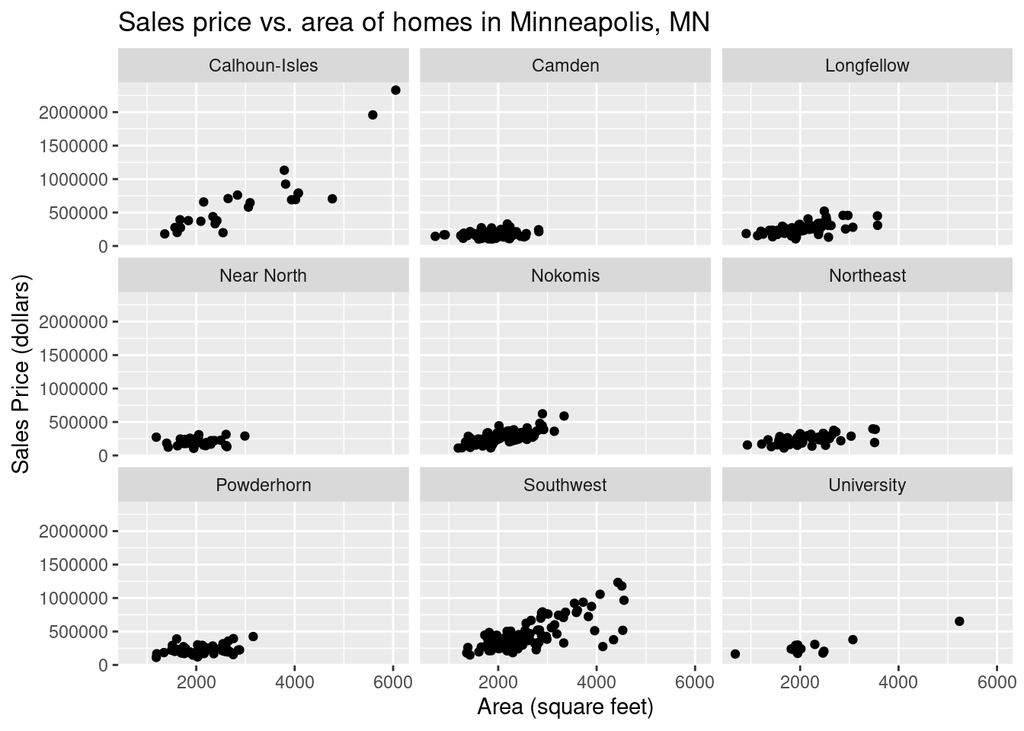

```r
ggplot(data = mn_homes,
       mapping = aes(x = area, y = salesprice)) +
   geom_point() +
   labs(title = "Sales price vs. area of homes in Minneapolis, MN",
        x = "Area (square feet)", y = "Sales Price (dollars)") +
   facet_wrap(~ community)
```

`facet_grid()`

- 2d grid
- rows ~ cols
- use . for no plot

`facet_wrap()`

- 1d ribbon wrapped into 2d

## Practice

1. Modify the code outline to make the changes described below.
- Change the color of the points to green.
- Add `alpha` to make the points more transparent.
- Add labels for the x axis, y axis, and the color of the points.
- Add an informative title.
- Consider using the `viridis` palette. (Note, you can’t do all of these things at once in terms of color, these are just suggestions.)

When you are finished, remove `eval = FALSE` and knit the file to see the changes.

Here is some starter code:

```r
ggplot(data = mn_homes,
       mapping = aes(x = lotsize, y = salesprice)) +
   geom_point(color = ____, alpha = ____) +
   labs(____)
```

2. Modify the code outline to make the changes described below.
- Create a histogram of `lotsize`.
- Modify the histogram by adding `fill = "blue"` inside the `geom_histogram()` function.
- Modify the histogram by adding `color = "red"` inside the `geom_histogram()` function.

When you are finished, remove `eval = FALSE` and knit the file to see the changes.

```r
ggplot(data = mn_homes,
       mapping = aes(x = _____)) +
  geom_histogram(fill = ____, color = ____) +
  labs(title = "Histogram of Lot Size" , x = "Size of Lot", y = "Number of Homes")
```

**Question:** What is the difference between the `color` and `fill` arguments?

3. Develop an effective visualization on your own using the code chunk provided below. Use three variables and at least one aesthetic mapping.

### Additional Resources

- https://ggplot2.tidyverse.org/
- https://raw.githubusercontent.com/rstudio/cheatsheets/master/data-visualization-2.1.pdf
- http://r-statistics.co/Top50-Ggplot2-Visualizations-MasterList-R-Code.html
- https://medium.com/bbc-visual-and-data-journalism/how-the-bbc-visual-and-data-journalism-team-works-with-graphics-in-r-ed0b35693535
- https://ggplot2-book.org/
- https://ggplot2.tidyverse.org/reference/geom_histogram.html
- https://rstudio.com/wp-content/uploads/2015/03/ggplot2-cheatsheet.pdf
- https://github.com/GraphicsPrinciples/CheatSheet/blob/master/NVSCheatSheet.pdf